# Qubits, Superpositions and Basics of Quantum Computing

Author: Sriram Sankaranarayanan, University of Colorado Boulder, srirams@colorado.edu

As we discussed last time, all modern digital computers manipulate binary numbers $0s$ and $1s$. They do so by mapping the logical values $0$ and $1$ to physical states of a system.

## Classical Digital Computer

In a modern computer, we have microprocessors that are capable of carrying out assembly language instructions. Inside the microprocessor, we have many digital logic circuits that manipulate information in the form of 1s and 0s to carry out the instructions. However, these 1s and 0s are themselves interpreted as physical states. For digital logic, high voltage in a wire $V \geq 2.5 \text{volts}$ is considered a $1$ and low voltage $V < 2.3 \text{volts}$ is mapped to a $0$. Then computations are carried out by logical gates such as AND, OR, NOT, NAND, NOR that are constructed using transistors. Memory is implemented using special circuits called `Flip-Flops`.

## Quantum Computer

Quantum computers also map information in the form of $0$s and $1$s to states of a system. However, these systems tend to be operated at conditions where the laws of quantum mechanics apply

Note: Strictly speaking quantum mechanical principles apply for all systems. However, for systems with large numbers of particles at room temperature, the behavior of individual particles aggregate into a system-wide behavior that is modeled by the equations of classical physics such as Newton's laws or Maxwell's equations.

For example, a trapped ion quantum computer (Cf. https://ionq.com/technology) is built by trapping ions of an element such as Ytterbium (Yb) in a rapidly oscillating electromagnetic field that keeps the ions stationary in space. The ions are also "cooled" so that they are in a known ground state. This is interpreted as a $0$. The trapped ion can be in a different state that is interpreted as a $1$. States of the ion can be manipulated using Laser pulses of precise frequency and durations. However, such a computer exhibits quantum phenomena that classical computers do not. Roughly, the most attractive features of quantum computing systems are as follows:

- The system can be placed in a *super-position* of states. I.e, it can be in one of many states at the same time. For example, an individual bit can at the same time be both a $0$ and a $1$! A system with $n$ quantum bits can simultaneously be in one of $2^n$ states, corresponding to all possible values that the $n$ bits can take.
  - When a system is in a super-position of states, we can perform certain operations on all the states in the super-position in parallel. This kind of parallelism can perform exponentially many computations in one step.
- However, if we attempted to read (mesaure) the state of the system (whether it is a 0 or a 1), the super-position collapses and the system is now in just a single state.
  - This places a limitation on how we can exploit quantum parallelism since even though a superposition can be in $2^n$ states at the same time, we can only read off one of them at any one time.
- Quantum algorithms are designed to cleverly exploit the properties of quantum systems to achieve speedups over what is possible using classical computers.

We will now start to formulate these mathematically so that we can describe how quantum computers work without worrying about how these workings are implemented in actual quantum computers.

## Recall: Complex Numbers

It is useful to quickly recall properties of complex numbers. Please refer to these notes: https://web.stanford.edu/~boyd/ee102/complex-primer.pdf

- The number $i = \sqrt{-1}$ is an imaginary square root of $-1$.
- A complex number can be written as $a + i b$ where $a, b$ are the real and imaginary parts, respectively.
- The modulus of a complex number $z = a + ib$ is given by $|z| = \sqrt{a^2 + b^2}$ and the argument (phase) is given by $\mathsf{arg}(z) = \tan^{-1}(\frac{b}{a})$.
- The conjugate of complex number $z = a + ib$ is given by $\overline{z} = a - ib $.
- For two complex numbers $z_1 = a_1 + i b_1$ and $z_2 = a_2 + i b_2$, we have $z_1 + z_2 = (a_1 + a_2) + i (b_1 + b_2)$ and $z_1 z_2 = (a_1 a_2 - b_1 b_2) + i (a_2 b_1 + a_1 b_2)$. Finally, we can reciprocate a complex number as $\frac{1}{z_1} = \frac{(a_1 - i b_1)}{a_1^2 + b_1^2}$, provided $a_1^2 + b_1^2 \not= 0$.
- A complex number $z$ with modulus $r$ and argument $\varphi$ can be written equivalently as: $ z = r \cos(\varphi) + i r \sin(\varphi) = r e^{ i \varphi}\,.$

## Recall: Vectors and Dot Products

Suppose we have two vectors of complex numbers $\vec{a} = \left( \begin{array}{c} a_1 \\ a_2 \\ \cdots \\ a_n \end{array} \right)$ and $\vec{b} = \left( \begin{array}{c} b_1 \\ b_2 \\ \cdots \\ b_n \end{array} \right)$ then we define their *dot product* or *inner product* as $\vec{a} \cdot \vec{b} = \sum_{i=1}^n \overline{a_i} b_i$ wherein $\overline{a_i}$ denotes the complex conjugate of $a_i$. Recall the following fact about vectors:

- The norm of the vector $\vec{a}$ (which is simply a measure of its "length") is the square root of its dot product with itself $||\vec{a}|| = \sqrt{\vec{a} \cdot \vec{a}} = \sqrt{\sum_{i=1}^n |a_i|^2 }$.
- A vector is called a *unit vector* if it has norm $1$: $||\vec{a}|| = 1$.
- The angle $\theta$ between two vectors $\vec{a}, \vec{b}$ satisfies $ \cos(\theta) = \frac{\vec{a} \cdot \vec{b}}{||\vec{a}|| ||\vec{b}||}$.
- In particular, two vectors are orthogonal if $\vec{a} \cdot \vec{b} = 0$. I.e, the angle between them is $90^{\circ}$.

## Qubit

$$\newcommand\ket[1]{\left|\,#1 \right\rangle} \newcommand\braket[2]{\left\langle\,#1\,\right|\left.\, #2\, \right\rangle} $$

A *qubit* is a quantum bit. In quantum computing, we will use the notation $\ket{\varphi}$ (pronounced *ket* phi ) to describe a system that is in some state $\varphi$.

$\ket{\varphi}$ is a (possibly infinite dimensional) vector whose entries describe the aspects of the state $\varphi$ that we may care about. We will not worry about what these aspects are. Technically, $\ket{\varphi}$ belongs to a separable Hilbert space. But for our purposes, we could think of it as a column vector with complex number entries.

Given two quantum states $\ket{\varphi} $ and $\ket{\psi}$, their inner product is written as $ \braket{\varphi}{\psi}$. In particular, In quantum physics, this is called the "quantum bracket". The norm is given by $\sqrt{\braket{\varphi}{\varphi}}$.

- All qubits are unit vectors in the Hilbert space: $\sqrt{\braket{\varphi}{\varphi}} = 1$.

### Pure States

We will assume that there are two orthogonal states $\ket{0}$ that is the state corresponding to the bit $0$ and $\ket{1}$ which is the state corresponding to the bit $1$. We call $\ket{0}, \ket{1}$ as the pure states of a single qubit.

- $\ket{0}$ and $\ket{1}$ are orthogonal: $\braket{0}{1} = \braket{1}{0} = 0$.

We will call $\ket{0}, \ket{1}$ the basis vectors.

### Superposition/Mixed States

In general, a single qubit quantum system can be written as the super position of two pure (basis) states: $$ \ket{\varphi} = \alpha \ket{0} + \beta \ket{1} $$ wherein we require $|\alpha|^2 + |\beta|^2 = 1$. This ensures that the norm $\braket{\varphi}{\varphi} = |\alpha|^2 + |\beta|^2 = 1$.

## Operations on Quantum States

At the heart of quantum computing, we will apply operations on qubits to transform them from one superposition into another. There are two types of operations in quantum computing : (a) measurements; and (b) quantum operations. Measurements are somehow considered *destructive* in that they will cause the superposition to collapse to one of its component pure states. Quantum operations on the other hand preserve superpositions in a manner of speaking, as we will see below.

### Measurement

When a quantum state $\ket{\varphi} = \alpha \ket{0} + \beta \ket{1} $ is measured (for this module, we will always make measurements along the basis $\ket{0}, \ket{1}$), it collapses to one of the pure (basis) states yielding $$ \ket{0}\ \text{with probability}\ |\alpha|^2,\ \ket{1}\ \text{with probability}\ |\beta|^2 $$

### Examples

- The pure state $\ket{0}$ when measures collapses to the pure state $\ket{0}$ with probability $1$ and the state $\ket{1}$ with probability $0$.
- Consider the super position $\ket{+} = \frac{1}{\sqrt{2}} \ket{0} + \frac{1}{\sqrt{2}}\ket{1} $. Note here that "+" is the name given to the state: we may as well called it $\ket{\varphi}$ or $\ket{\xi}$ if you prefer your kets to be named with Greek letters.
  - When measured $\ket{+}$ collapses into $\ket{0}$ with probability $\frac{1}{2}$ or $\ket{1}$ with probability $\frac{1}{2}$.
- Consider the super position $\ket{\phi} = \frac{\sqrt{3}}{2} \ket{0} - \frac{1+i}{2 \sqrt{2}} \ket{1}$. Here $\alpha = \frac{\sqrt{3}}{2}$ and $\beta = \frac{(1+i)}{2 \sqrt{2}}$.
  - When measured it collapses to state $\ket{0}$ with probability $\frac{3}{4} = |\alpha|^2$ and $\ket{1}$ with probability $\frac{1}{4} = |\beta|^2$.

## Quantum Operations on Qubits

Given a qubit $\ket{\varphi} = \alpha \ket{0} + \beta \ket{1}$, we can perform a quantum operation $U$ that transforms it into another qubit $\ket{\psi}$. All quantum operators are linear. Therefore, we can define any such operation $U$ by first defining it on the bases:

- $\ket{0'} = U \ket{0}$ and $\ket{1'} = U \ket{1}$. If we think of $U$ as a "change of basis" operator, it transform the pure (basis) state $\ket{0}$ into state $\ket{0'}$ and likewise $\ket{1}$ into $\ket{1'}$.
- Therefore, $U \ket{\varphi} = U (\alpha \ket{0} + \beta \ket{1} ) = \alpha U \ket{0} + \beta U \ket{1} = \alpha \ket{0'} + \beta\ket{1'}$.
- $\ket{0'}$ and $\ket{1'}$ must have norm $1$: $\braket{0'}{0'} = 1$ and $\braket{1'}{1'} = 1$.
- Finally, $U$ must keep keep the $90^\circ$ angle between $\ket{0'}$ and $\ket{1'}$: $\braket{0'}{1'} = 0$.

All of the conditions above together imply that any quantum operator must be *unitary*. We will define this concept more formally in a second. But first let's give examples.

### Example # 1 : Hadamard Gate

The Hadamard gate is a unitary operator $H$ that has the following properties:

- $H \ket{0} = \ket{+} = \frac{1}{\sqrt{2}}( \ket{0} + \ket{1})$
- $H \ket{1} = \ket{-} = \frac{1}{\sqrt{2}}(\ket{0} - \ket{1}) $

Verify that $$ \braket{+}{+} = \frac{1}{\sqrt{2}^2} \braket{0}{0} + \frac{1}{\sqrt{2}^2} \braket{1}{0} +\frac{1}{\sqrt{2}^2} \braket{0}{1} + \frac{1}{\sqrt{2}^2} \braket{1}{1}= 1 $$, $$\braket{-}{-} = \frac{1}{\sqrt{2}^2} \braket{0}{0} + \frac{1}{(-\sqrt{2})^2} \braket{1}{1} = 1$$ $$\braket{+}{-} = \frac{1}{\sqrt{2}\sqrt{2}} \braket{0}{0} + \frac{1}{\sqrt{2} (-\sqrt{2}} \braket{1}{1} = \frac{1}{2} - \frac{1}{2} = 0$$

The operator is therefore unitary.

Suppose we had a qubit $\ket{\varphi} = \frac{\sqrt{3}}{2} \ket{0} + \frac{1}{2} \ket{1}$ then

$$ \begin{array}{rl} H\ket{\varphi} & = \frac{\sqrt{3}}{2} H \ket{0} + \frac{1}{2} H \ket{1} \\ & = \frac{\sqrt{3}}{2} \ket{+} + \frac{1}{2} \ket{-} \\ & = \frac{\sqrt{3} + 1}{2 \sqrt{2}} \ket{0} + \frac{\sqrt{3} -1}{2 \sqrt{2}} \ket{1} \\ \end{array} $$

Suppose $\ket{\psi} = H \ket{\varphi}$ then note that measuring $\ket{\psi}$ will cause a collapse on to $\ket{0}$ with probability $\frac{1}{2} + \frac{\sqrt{3}}{4}$ and $\ket{1}$ with probability $\frac{1}{2} - \frac{\sqrt{3}}{4}$.

Note that the Hadamard gate can be written as a matrix

$$ H = \left( \begin{array}{cc} \frac{1}{\sqrt{2}} & \frac{1}{\sqrt{2}} \\ \frac{1}{\sqrt{2}} & -\frac{1}{\sqrt{2}} \\ \end{array} \right) $$

Such that for any state $\ket{\varphi} = \alpha \ket{0} + \beta \ket{1}$, applying the Hadamard gate yields $\ket{\psi} = \alpha' \ket{0} + \beta' \ket{1}$ wherein

$$\left(\begin{array}{c} \alpha' \\ \beta' \\ \end{array} \right) = H \times \left(\begin{array}{c} \alpha \\ \beta \\ \end{array} \right)$$

### Example # 2: Quantum Not Gate

The quantum not-gate is an important gate represented by the unitary operator $X$:

- $X \ket{0} = \ket{1}$
- $X \ket{1} = \ket{0}$

Therefore, $X (\alpha \ket{0} + \beta \ket{1}) = \alpha X \ket{0} + \beta X \ket{1} = \alpha \ket{1} + \beta \ket{0}$. The operator is represented by the matrix

$$X = \left( \begin{array}{cc} 0 & 1 \\ 1 & 0 \\ \end{array}\right)$$

### Example # 3: Phase Gate

The quantum phase gate applies a "phase" $\theta$ and is defined by the unitary operator $P(\theta)$:

- $P(\theta) \ket{0} = \ket{0}$
- $P(\theta) \ket{1} = e^{i \theta} \ket{1}$.

  The operator is represented by the matrix:

  $$P(\theta) = \left( \begin{array}{cc} 1 & 0 \\ 0 & e^{i \theta} \\ \end{array}\right)$$

## Unitary Matrices

Similarly, for any unitary operator $U$, we can define a unitary matrix with complex number entries:

$$U = \left( \begin{array}{cc} U_{11} & U_{12} \\ U_{21} & U_{22} \\ \end{array} \right) $$

such that for any state $\ket{\varphi} = \alpha \ket{0} + \beta \ket{1}$, applying the operator $U$ yields $\ket{\psi} = \alpha' \ket{0} + \beta' \ket{1}$ wherein

$$\left(\begin{array}{c} \alpha' \\ \beta' \\ \end{array} \right) = U \times \left(\begin{array}{c} \alpha \\ \beta \\ \end{array} \right)$$

The columns of $U$ specify $U \ket{0} $ and $U\ket{1}$:

- $U \times \left( \begin{array}{c} 1 \\ 0 \\ \end{array} \right) = \left( \begin{array}{c} U_{11} \\ U_{21} \\ \end{array} \right)$. In terms of kets, we can write this as $U \ket{0} = U_{11} \ket{0} + U_{21} \ket{1}$.
- Likewise, $U \times \left( \begin{array}{c} 0 \\ 1 \\ \end{array} \right) = \left( \begin{array}{c} U_{12} \\ U_{22} \\ \end{array} \right)$. In terms of kets, we can write this as $U \ket{1} = U_{12} \ket{0} + U_{22} \ket{1}$.

The unitary matrix has the property that $U^\dagger U = U U^\dagger = I$ wherein $U^{\dagger}$ is called the adjoint matrix of $U$ given by transposing $U$ and taking the complex conjugate of all the entries:

$$U^{\dagger} = \left( \begin{array}{cc} \overline{U}_{11} & \overline{U}_{21} \\ \overline{U}_{12} & \overline{U}_{22} \\ \end{array} \right) $$

and $I$ is the identity matrix :

$$I = \left( \begin{array}{cc} 1 & 0 \\ 0 & 1 \\ \end{array}\right)$$

**Verify** that $H$ is a unitary operator by checking that its matrix is unitary.

$$H^{\dagger} = \left( \begin{array}{cc} \frac{1}{\sqrt{2}} & \frac{1}{\sqrt{2}} \\ \frac{1}{\sqrt{2}} & -\frac{1}{\sqrt{2}} \\ \end{array} \right) (= H )$$

We have $H H^{\dagger}$ (and $H^{\dagger} H $) as $$H \times H^{\dagger} = \left(\begin{array}{cc} \frac{1}{\sqrt{2}}\times \frac{1}{\sqrt{2}} + \frac{1}{\sqrt{2}}\times \frac{1}{\sqrt{2}} & \frac{1}{\sqrt{2}}\times \frac{1}{\sqrt{2}} - \frac{1}{\sqrt{2}}\times \frac{1}{\sqrt{2}} \\ \frac{1}{\sqrt{2}}\times \frac{1}{\sqrt{2}} - \frac{1}{\sqrt{2}}\times \frac{1}{\sqrt{2}} & \frac{1}{\sqrt{2}}\times \frac{1}{\sqrt{2}} + \frac{-1}{\sqrt{2}}\times \frac{-1}{\sqrt{2}}\\ \end{array}\right) = I\,.$$

**Verify** that the operator $T$ with the matrix

$$T = \left( \begin{array}{cc} 1 & 0 \\ 0 & \frac{1}{\sqrt{2}} ( 1+ i) \\ \end{array}\right)$$

is unitary. Notice that $T = P(\frac{\pi}{4})$, the phase gate with $\theta = 45^{\circ}$.

**Verify** that the $X$ (quantum-not) gate with the matrix

$$X = \left( \begin{array}{cc} 0 & 1 \\ 1 & 0 \\ \end{array}\right)$$

is unitary.

## Computing with Single Qubit

We can now talk about single qubit quantum circuits. They are rather simple: we start with a single qubit that is initialized to $\ket{0}$ (or typically some known basis state) and apply a series of gates followed by a final measurement. The measurement's outcome will be probabilistic yielding $\ket{0}, \ket{1}$ with probabilities that depend on the superposition that the circuit creates after applying all the quantum operations. Once the qubit is measured, it collapses into a $\ket{0}$ or $\ket{1}$ state.

We will demonstrate some examples using IBM QISKIT quantum circuit building toolbox and simulator. This is a powerful toolbox that allows us to construct quantum circuit and even run them on IBM's quantum computer that is available.

### Example 1

We build a single qubit circuit. The qubit is assumed to be in state $\ket{0}$ at the start (this will be considered the case for all circuits we build unless otherwise specified).

1. Apply the Hadamard gate to the qubit
2. Apply the $T = P(\frac{\pi}{4})$ gate
3. Apply a Hadamard gate to the result.
4. Perform a measurement.

The circuit therefore represents a measurement of the qubit

$\begin{array}{rl} \ket{\psi} & = H \times T \times H \times \ket{0} \\ & = H \times T \times \left( \frac{1}{\sqrt{2}} ( \ket{0} + \ket{1}) \right) \\ & = H \times \left( \frac{1}{\sqrt{2}}( \ket{0} + e^{i \frac{\pi}{4}} \ket{1}) \right) \\ & = H \times \left( \frac{1}{\sqrt{2}}\ket{0} + \frac{1 + i}{2 } \ket{1} \right) \\ & = \frac{1}{\sqrt{2}} ( \frac{1}{\sqrt{2}} (\ket{0} + \ket{1})) + \frac{1 + i}{2 } \frac{1}{\sqrt{2}} (\ket{0} - \ket{1})\\ & = \frac{ \sqrt{2} + 1 + i}{2 \sqrt{2}} \ket{0} + \frac{\sqrt{2} -1 - i}{2 \sqrt{2}} \ket{1} \\ \end{array} $

Measuring $\ket{\psi}$ will give us $\ket{0}$ with probability $ \frac{1}{8} ( 4 + 2 \sqrt{2}) = \frac{1}{2} + \frac{1}{2 \sqrt{2}} \approx 0.8535$ and $\ket{1}$ with probability $\approx 0.1464$.

```
 > Probability distribution: Probability of |0> : 0.8525 Probability of |1> : 0.1475
```

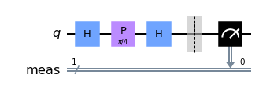

```python
# modified from IBM Qiskit tutorial: https://github.com/Qiskit/qiskit
import numpy as np
from qiskit import QuantumCircuit
from qiskit.primitives.sampler import Sampler

# create a single qubit circuit
# - Qubit is initially |0>
# Apply a Hadamard gate,
# Followed by the T gate
# and then a measurement

qc0 = QuantumCircuit(1)# A quantum circuit with a single qubit. Qubits are indexed starting from 0
qc0.h(0)          # apply hadamard on qubit # 0
qc0.p(np.pi/4,0)  # a T gate is a phase gate with phase pi/4: apply it to qubit 0
qc0.h(0)# apply a hadamard to qubit 0
# 2. Measure all the qubits in this case the single qubit
qc_measured = qc0.measure_all(inplace=False)

# 3. Execute the circuit using sampler.

sampler = Sampler()
job = sampler.run(qc_measured, shots=10000)# simulate the measurement circuit 10,000 times
result = job.result() # get the result from the simulations
print(f" > Probability distribution: Probability of |0> : {result.quasi_dists[0][0]} Probability of |1> : {result.quasi_dists[0][1]} ")
qc_measured.draw('mpl')
```